# EDS 222: Assignment 02 (due: Oct 13, 9am)

Elke Windschitl

2022-10-12

# Question 1: Probability density functions in `R`

`R` has many built-in functions that let you describe, analyze, and sample from common probability density functions. For example, if you type `?stats::Normal` in your console, you’ll see documentation on all the functions relevant to the normal distribution. These functions include:

Recall that the normal distribution is a family of distributions that are symmetric and do not have long tails. They each have different means $\mu$ and standard deviations $\sigma$.

- `dnorm(x, mean = 0, sd = 1)`, which returns the *density* of the normal distribution evaluated at whatever values you pass in via `x`. You can think of the output of `dnorm()` as the *height* of the normal pdf at the value `x`. Note that this function defaults to a normal distribution with $\mu = 0$ and $\sigma = 1$, but you can of course change that.
- `pnorm(q, mean = 0, sd = 1)`, which returns the *cumulative probability* of the normal distribution evaluated at whatever values you pass in via `q`. You can think of the output of `pnorm()` as the *area* under the pdf to the left of the value `q`. Again, note the default distribution parameters $\mu$ and $\sigma$.

## Question 1.1

```r
x = seq(-4, 4, 0.01)
```

Use `dnorm()` to compute the density of the normal pdf for all values in the `x` vector generated above, using $\mu = 0$ and $\sigma = 1$. Use `geom_polygon()`, `geom_line()`, or `geom_point()` (take your pick) to plot this pdf over the support given in `x`.

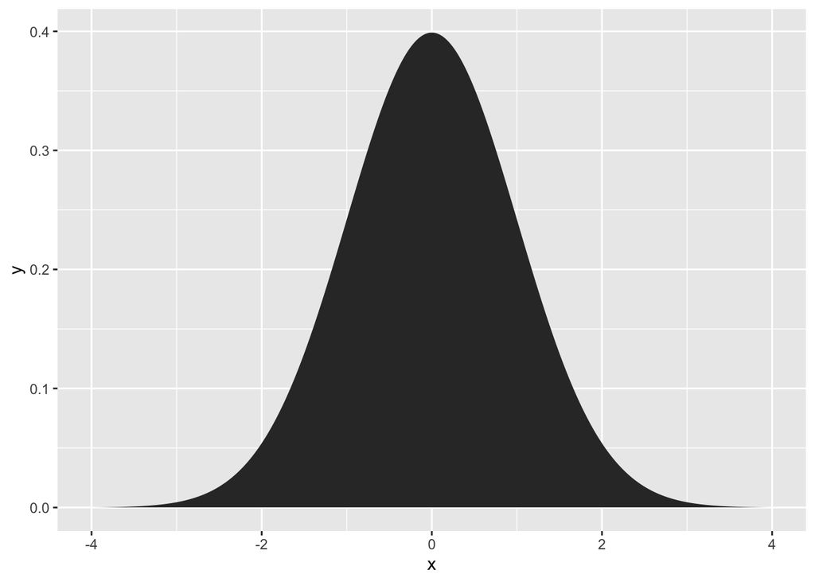

```r
# Compute the density of the normal pdf for all values in x and save as y
y <- dnorm(x, mean = 0, sd = 1)

# Combine x and y into a dataframe then plot the pdf
df <- as.data.frame(cbind(x,y))
ggplot(data = df, aes(x = x, y = y)) +
  geom_polygon()
```

```r
# Check that the area under the whole curve = ~1
#pnorm(x, mean = 0, sd = 1)
```

## Question 1.2

Use the densities you generated in 1.1 to calculate the probability that a random variable distributed normally with mean 0 and standard deviation 1 falls between -2 and 2.[^2]

Hint: Remember that
$$Pr(A\leq x \leq B)
= \int_A^B f(x)dx$$
where the integral is a fancy way to tell you to sum up $f(x)$ over values of $x$ from $A$ to $B$.

```r
# I'm not using the densities I generated in 1.1 here... so I also tried a second method below
integrate(dnorm, -2, 2)
```

```
## 0.9544997 with absolute error < 1.8e-11
```

```r
# An alternative method by summing the values of y between -2 < x < 2 and  multiplying by the width of the intervals
i <- df[df$x > -2 & df$x <2,]
sum(i$y) * 0.01 #the size of the sliver
```

```
## [1] 0.953958
```

```r
# Something else to try... this is the same as the first above, great. But once again doesn't feel like I used the density values from 1.1.
pnorm(2, 0, 1) - pnorm(-2, 0, 1)
```

```
## [1] 0.9544997
```

## Question 1.3

Suppose $\sigma=2$ instead. Qualitatively, how would your answer to Question 1.2 change? Why?

**Increasing the SD from 1 to 2 would make the answer to 1.2 decrease. It would decrease because the spread of x would be wider and probabilities outside of the -2 to 2 window would be greater. That would mean the sum of the probabilities between -2 to 2 would be less.**

## Question 1.4

An analogous set of functions computes densities and probabilities for the **log normal** distribution. These functions are `dlnorm()` and `plnorm()` and operate as above for the normal distribution functions.

Use `plnorm()` under default parameters to compute the probability that a random variable distributed log normal takes on a value above 2. Use `pnorm()` to compute the corresponding probability for the normal distribution under default parameters. Why are these values so different?

**The values are very different because taking the log of the normal distribution makes any value < 0 have a probability of occurring 0. The log distribution has a long right tail and has more “mass” beyond the value 2, and therefore values above 2 have a greater chance of being randomly selected.**

```r
# Probability random variable distributed log normal takes value > 2
plnorm(2, lower.tail = FALSE)
```

```
## [1] 0.2441086
```

```r
# Probability random variable distributed normally takes value > 2
pnorm(2, lower.tail = FALSE)
```

```
## [1] 0.02275013
```

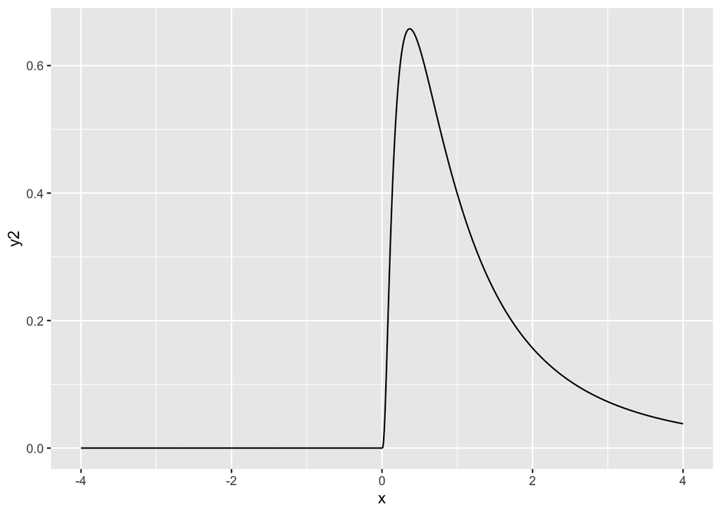

```r
# Take a look at what this graph looks like
y2 <- dlnorm(x)
df2 <- as.data.frame(cbind(x,y2))
ggplot(data = df, aes(x = x, y = y2)) +
  geom_line()
```

# Question 2: Climate summary statistics

In the following questions, you’ll be working with climate data from Colombia. These data were obtained from the [ERA5 database](https://www.ecmwf.int/en/forecasts/datasets/reanalysis-datasets/era5), a product made available by the European Centre for Medium-Range Weather Forecast. The high-resolution hourly gridded data were aggregated to the municipality by month level – that is, each observation in these data report a monthly average temperature value and a monthly cumulative precipitation value for one of the 1,123 municipalities across the country.

Note: The computational techniques we use to go from raw, spatial, gridded data to a tabular dataset at an administrative level are really valuable for environmental data science. Between Ruth and I, we’re hoping to cover some of these topics later in the quarter!

These data – stored in `colombia_climate.csv` – cover all municipalities for the period 1996 to 2015. Climate scientists tend to describe the “climate” of a location as the probability density function of a large set of climate variables over about a 30 year period. We only have 20 years, but we will consider our sample as randomly drawn temperature and precipitation realizations from the “climate” p.d.f. over this period. We are aiming to draw conclusions about the Colombian climate using this sample of temperature and precipitation observations.

## Question 2.1

Read these data into `R` using the `read.csv()` function.

See the README.rtf file for details on the variables in `colombia_climate.csv`.

For each of the temperature and rainfall variables, create a histogram that shows the distribution of the variable across the entire sample. For each variable, answer the following questions:

- Is the distribution symmetric or skewed?
  - **Precipitation: The distribution is skewed with a long right tail**
  - **Temperature: The distribution is asymmetric and skewed**
- Is there a long tail (or two), or does this distribution look approximately normally distributed?
  - **Precipitation: Yes, there is a long right tail**
  - **Temperature: There is not really a long tail, but there is a second peak to the right of the main peak and a short tail**
- Is the distribution unimodal, bimodal, or multimodal?
  - **Precipitation: The distribution is unimodal**
  - **Temperature: The distribution is bimodal**

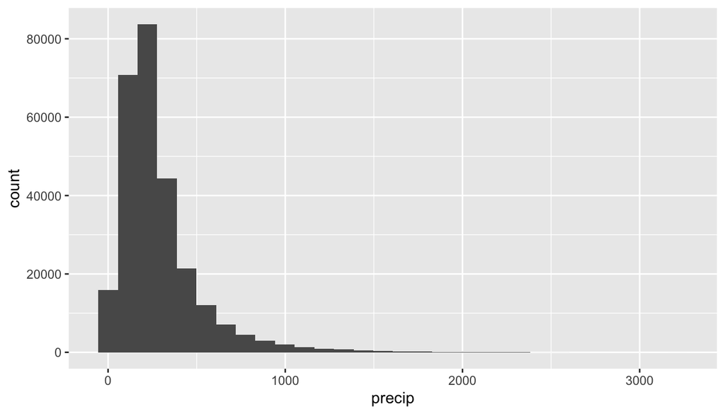

```r
# Read in the data
climate <- read_csv(file.path(datadir, "colombia_climate.csv"))

# Create a histogram of the precipitation data
ggplot(climate, aes(x = precip)) +
  geom_histogram(bins = 30)
```

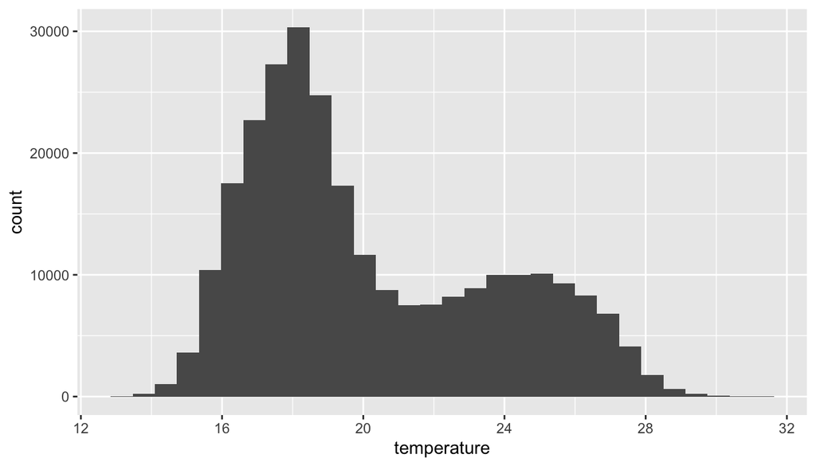

```r
# Create a histogram of the temperature data
ggplot(climate, aes(x = temperature)) +
  geom_histogram(bins = 30)
```

## Question 2.2

Given your answers to 2.1 above, do you expect the mean of temperature to differ from the median? Is it likely to be about the same, smaller, or larger? What about precipitation?

**I would expect the mean of the precipitation data to be larger than the median for the same reasons as above. The long right tail adds more values that are large that “pull” the mean up.**

## Question 2.3

Anthropogenic climate change is expected to raise temperatures across Colombia, increase total precipitation, and increase variability in precipitation. Compute the mean, the median, and the standard deviation of each climate variable in:

- All years before and including 2005
- All years after 2005

Put your summary statistics into a table (or two tables, whatever is easiest). Are the changes you see between the pre-2005 and post-2005 periods consistent with climate change? Explain why.

**Yes, I would say these changes are consistent with climate change. The precipitation mean and median both increase indicating a changing climate. The temperatures don’t change, but temperature is only one variable within the broad term “climate.”**

```r
# Filter for years 2005 and before
before05 <- climate %>% filter(year <= 2005)
# Filter for years after 2005
after05 <- climate %>% filter(year > 2005)

# Assign columns to variables
precip_b05 <- before05$precip
precip_a05 <- after05$precip
temp_b05 <- before05$temperature
temp_a05 <- after05$temperature

# Make a summary table
climate_vars_table <- tribble(
  ~climate_var, ~mean, ~median, ~sd,
  "precip pre '05",  mean(precip_b05), median(precip_b05), sd(precip_b05),
  "precip post '05", mean(precip_a05), median(precip_a05), sd(precip_a05),
  "temp pre '05",  mean(temp_b05), median(temp_b05), sd(temp_b05),
  "temp post '05", mean(temp_a05), median(temp_a05), sd(temp_a05)
)
climate_vars_table
```

```
## # A tibble: 4 × 4
##   climate_var      mean median     sd
##   <chr>           <dbl>  <dbl>  <dbl>
## 1 precip pre '05  255.   205.  216.
## 2 precip post '05 313.   246.  253.
## 3 temp pre '05     20.2   19.0   3.45
## 4 temp post '05    20.2   19.0   3.50
```

## Question 2.4

The histograms and summary statistics should make you concerned that these data are not normally distributed. As we will show later in the course, it’s often very helpful to have normally distributed data before we do things like linear regressions or hypothesis testing. Here, let’s use a Q-Q plot to assess the normality of our sample data.

- Use `geom_qq()` and `geom_qq_line()` in `ggplot2` to make a Q-Q plot for each variable.

  `geom_qq_line()` lets you draw a line indicating where the sample quantiles would lie if the data were normally distributed.
- What do you conclude about the normality of these two variables?

  **I would conclude from the qq plots that neither precipitation or temperature have normal distribution. In both plots we see the expected quantiles deviating from the theoretical quantiles.**

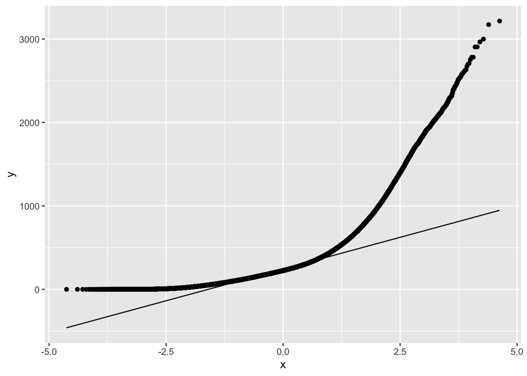

```r
# Create a qq plot for the precipitation
precip_qq_plot <- ggplot(climate, aes(sample = precip)) +
  geom_qq() +
  geom_qq_line()
precip_qq_plot
```

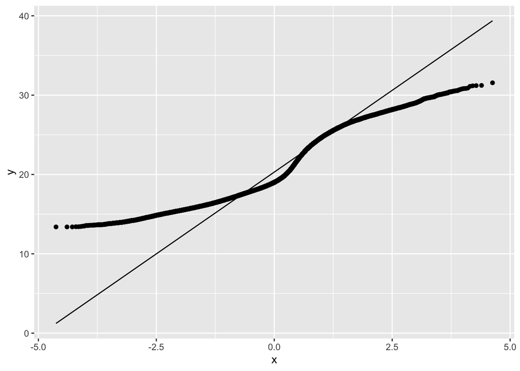

```r
# Create a qq plot for the temperature
temp_qq_plot <- ggplot(climate, aes(sample = temperature)) +
  geom_qq() +
  geom_qq_line()
temp_qq_plot
```

## Question 2.5

When our sample observations are not normally distributed, we often rely on nonlinear transformations to reshape our data. If we compute a nonlinear transformation on our underlying data and they then look closer to normal, we can use this transformed version of our variable in later statistical analysis.

Any mathematical operation that is a nonlinear function of the underlying variable can be considered a “nonlinear transformation”. For example, $x^2$ and $log(x)$ are both nonlinear transformations.

Because we tend to see a lot of variables in the world that follow the lognormal distribution, a very common nonlinear transformation is the natural logarithm. Transform the precipitation data by taking the natural logarithm. Then remake your Q-Q plot – does your variable (defined as `log(precip)`) now look closer to normally distributed? What can you learn about where the data diverge from the normal distribution?

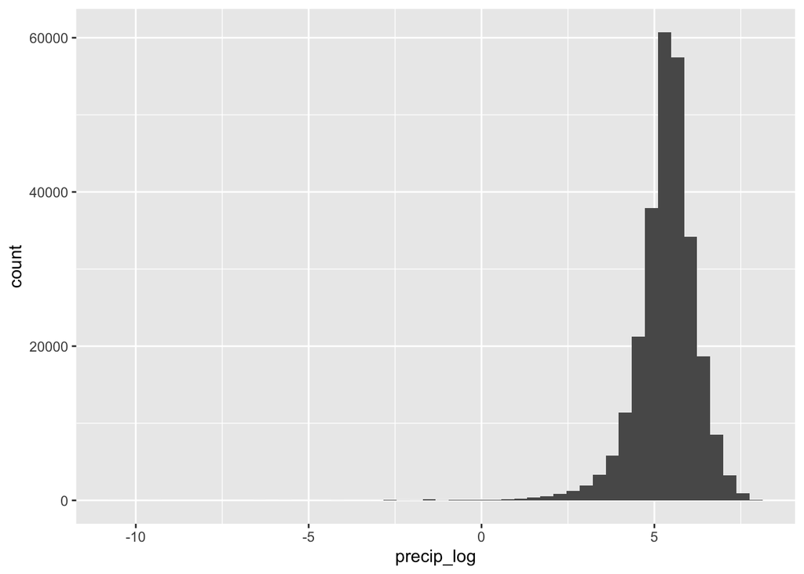

```r
# Take the log of precip
climate_log <- climate %>%
  mutate(precip_log = log(precip))

# Plot the histogram to check if it is normal
ggplot(climate_log, aes(x = precip_log)) +
  geom_histogram(bins = 50)
```

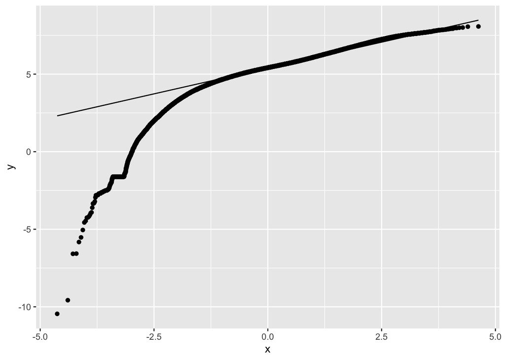

```r
# Make a qq plot to check if it is normal
precip_log_qq <- ggplot(climate_log, aes(sample = precip_log)) +
  geom_qq() +
  geom_qq_line()
precip_log_qq
```